# team

Rushal Sohal, Rohan Mishra; github: rsohal, rohmish

2/12/2020

## **Lab2**

```r
choco <- read.csv("https://xdaiisu.github.io/ds202materials/hwlabs/choco.csv")
head(choco)
```

```
##    Company Specific.Bean.Origin  REF Review.Date Cocoa.Pct Company.Location
## 1 A. Morin          Agua Grande 1876        2016        63           France
## 2 A. Morin                Kpime 1676        2015        70           France
## 3 A. Morin               Panama 1011        2013        70           France
## 4 A. Morin           Madagascar 1011        2013        70           France
## 5 A. Morin               Brazil 1011        2013        70           France
## 6 A. Morin             Equateur 1011        2013        70           France
##   Rating Bean.Type Broad.Bean.Origin
## 1   3.75                    Sao Tome
## 2   2.75                        Togo
## 3   2.75                      Panama
## 4   3.00   Criollo        Madagascar
## 5   3.25                      Brazil
## 6   3.75                     Ecuador
```

```r
library(plyr)
```

```r
length(choco$Rating)
```

```
## [1] 1852
```

1852 chocolate bars were rated.

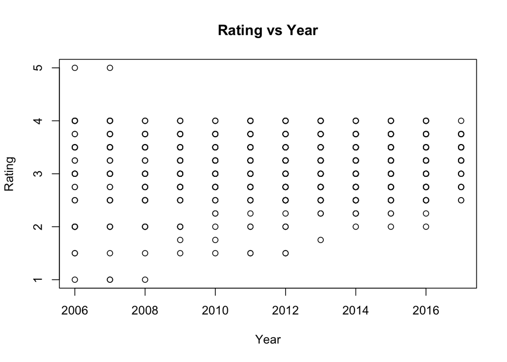

```r
plot(choco$Review.Date, choco$Rating, main="Rating vs Year", xlab="Year", ylab="Rating")
```

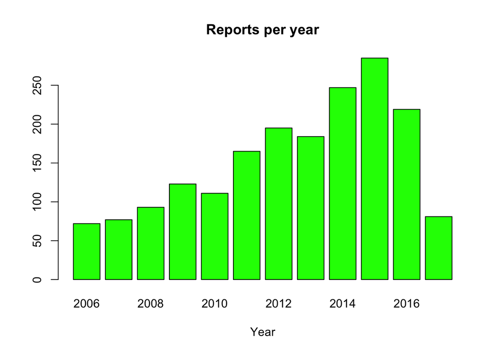

```r
tmp <- table(choco$Review.Date)
barplot(tmp, main="Reports per year", xlab="Year", col="green")
```

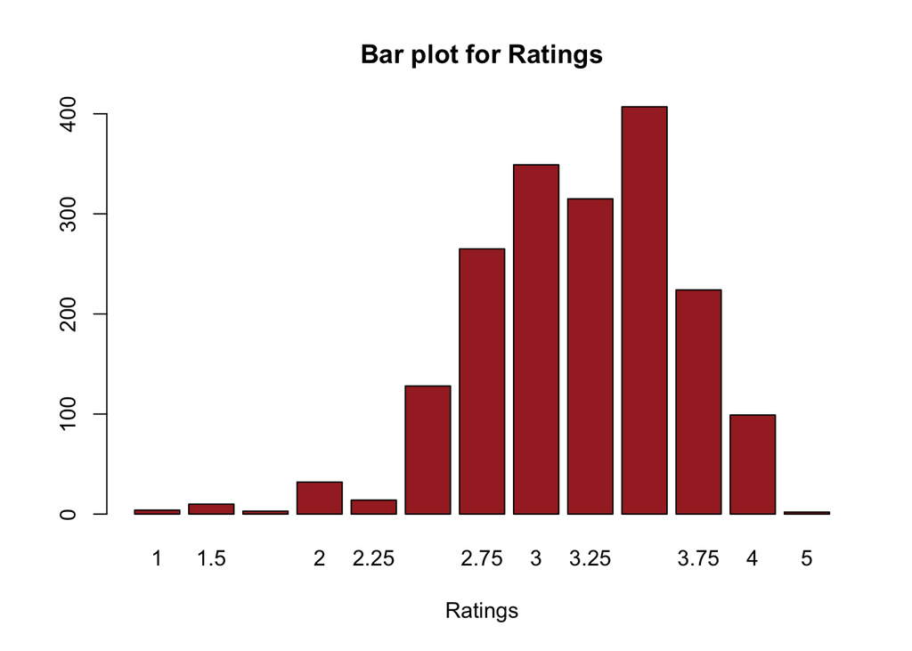

```r
tmp <- table(choco$Rating)
barplot(tmp, main="Bar plot for Ratings", xlab="Ratings", col="brown")
```

3. *Most Ratings = Highest number of data points*

```r
count(choco, "Company.Location")
```

```
##     Company.Location freq
## 1          Amsterdam    6
## 2          Argentina    9
## 3          Australia   50
## 4            Austria   27
## 5            Belgium   40
## 6            Bolivia    2
## 7             Brazil   18
## 8             Canada  132
## 9              Chile    2
## 10          Colombia   23
## 11        Costa Rica    9
## 12    Czech Republic    1
## 13           Denmark   16
## 14 Domincan Republic    5
```

[output cut: 47 more lines]

The top 3 locations are U.S.A., France, Canada.

```r
aggregate(choco[,7], list(choco$Company.Location), mean)
```

```
##              Group.1        x
## 1          Amsterdam 3.333333
## 2          Argentina 3.305556
## 3          Australia 3.360000
## 4            Austria 3.259259
## 5            Belgium 3.093750
## 6            Bolivia 3.250000
## 7             Brazil 3.388889
## 8             Canada 3.312500
## 9              Chile 3.750000
## 10          Colombia 3.173913
## 11        Costa Rica 3.138889
## 12    Czech Republic 2.750000
## 13           Denmark 3.312500
## 14 Domincan Republic 3.200000
```

[output cut: 47 more lines]

Canada = 3.31 France = 3.25 U.S.A. = 3.16

Canada has the highest average Rating and U.S.A has the least.

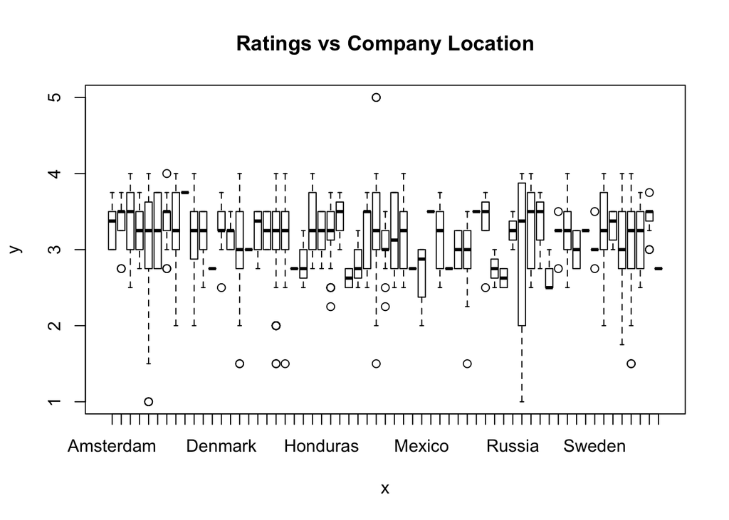

```r
plot(choco$Company.Location, choco$Rating, main="Ratings vs Company Location")
```

## What is the corelation between rating and the Company?

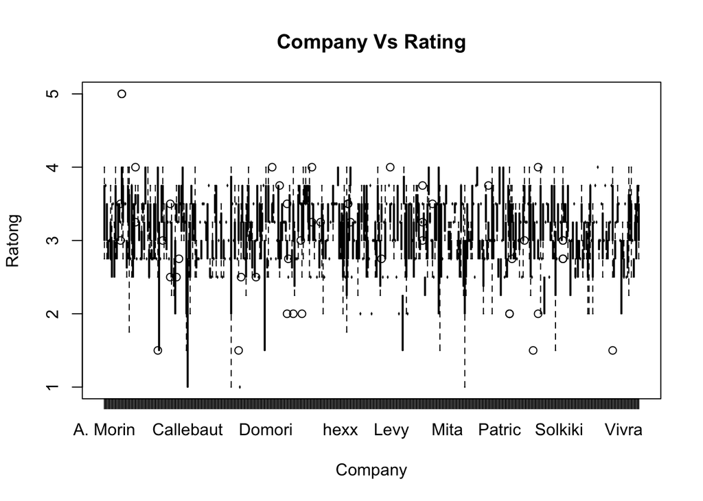

```r
plot(choco$Company, choco$Rating,main = "Company Vs Rating", xlab = "Company", ylab = "Ratong")
```

The Ratings tend to stay around the 3 mark for all the companies. However, Callebaut has the lowest rating in the group.

## The workflow was really nice and easy to get into rhythm with after work was delegated. As soon as we decided on our roles in the lab, we met up and complete the lab very quickly and efficiently. This fares better than Lab 1 as we understand git and R studio better now. So as a result we were successful in completing the lab in a way we are happy with.